# Treg/Tconv: comparison of Duguet’s data set with expression and proteomic datasets

Marie Locard-Paulet

2016-12-16

Here I want to compare our dataset with previous works. I will work with the supplementary data of two papers:

*Foxp3 Transcription-Factor-Dependent and -Independent Regulation of the Regulatory T Cell Transcriptional Signature. Jonathan A. Hill, Markus Feuerer, Kaley Tash, Sokol Haxhinasto, Jasmine Perez, Rachel Melamed, Diane Mathis, and Christophe Benoist1,*

DOI 10.1016/j.immuni.2007.09.010

*Transcription Factor 7 Limits Regulatory T Cell Generation in the Thymus. Melanie M. Barra, David M. Richards, Jenny Hansson, Ann-Cathrin Hofer, Michael Delacher, Jan Hettinger, Jeroen Krijgsveld and Markus Feuerer*

J Immunol published online 31 August 2015

The table with our MS results is the table (input table) `OutputTables/TotalAnalysisTconvTreg.txt`.

# Comparison with the expression dataset

Hill et al. 2007.

I use the expression data file `Raw/ExpressionData/GSE7460_series_matrix.txt` downloaded from the [Omnibus expression datasets webpage](http://www.ncbi.nlm.nih.gov/geo/). I have computed a ratio of normalised intensities Treg/Tconv (Markdown file `ExpressionAnalysis.Rmd` in the `ExpressionData` folder). All is saved in the file `ExpData.Rdata` that I load (`nmat` contains the fold changes ratio, `mat3` the raw expression values).

- I perform linear regressions first, then I make a graphical representation.
- In the expression table, I indicate wich genes are not present in our MS data set by adding a column called “PresenceInOurDataset”: “Present in our MS dataset” means we quantify the corresponding protein; “not in our MS dataset” means that we don’t identify the corresponding protein in our MS dataset.
- I then add a column named “MeanExpression” to our restult table that contains the mean expression observed for the corresponding protein in the expression dataset.

The final table is saved as `OutputTables/2PepOrMore/SignatureFoxp3.txt`.

There are some issues with name genes for the mapping.

| name in our data set | name in the expression data set |
| --- | --- |
| Folr4 | Izumo1r |
| Gbp4 | Gbp3 |
| Ca2 | Car2 |

I manually map these.

```r
tab1$MeanExpression[tab1$Gene.names=="Folr4"] <- as.numeric(means[names(means)=="Izumo1r"])[!is.na(as.numeric(means[names(means)=="Izumo1r"]))]
tab1$MeanExpression[tab1$Gene.names=="Gbp4"] <- as.numeric(means[names(means)=="Gbp3"])[!is.na(as.numeric(means[names(means)=="Izumo1r"]))]
tab1$MeanExpression[tab1$Gene.names=="Ca2"] <- as.numeric(means[names(means)=="Car2"])[!is.na(as.numeric(means[names(means)=="Izumo1r"]))]

tab10 <- tab1
tab1 <- tab1[!is.na(tab1$MeanExpression),]
ngenes <- length(unique(tab1$Gene.names)) # number of unique genes in our dataset

#colours for plot:
col <- rep("Not", nrow(tab1))
col[abs(tab1$MeanExpression) >= 2 | abs(tab1$FC) >= 2] <- "Above 2"
col[tab1$Gene.names=="Themis"] <- "Themis"
text <- rep(NA, nrow(tab1))
text[abs(tab1$MeanExpression) >= 2 | abs(tab1$FC) >= 2] <- tab1$Gene.names[abs(tab1$MeanExpression) >= 2 | abs(tab1$FC) >= 2]
text[tab1$Gene.names=="Themis"] <- "Themis"
tab1 <- cbind(tab1, "col" = col, "lab" = text)

lrd <- lm(tab1$FC~tab1$MeanExpression)
summary(lrd)
```

```
##
## Call:
## lm(formula = tab1$FC ~ tab1$MeanExpression)
##
## Residuals:
##     Min      1Q  Median      3Q     Max
## -2.6751 -0.2301 -0.0325  0.1966  3.8689
##
## Coefficients:
##                      Estimate Std. Error t value Pr(>|t|)
## (Intercept)         -0.018165   0.007391  -2.458    0.014 *
## tab1$MeanExpression  1.009454   0.019990  50.497   <2e-16 ***
## ---
## Signif. codes:  0 '***' 0.001 '**' 0.01 '*' 0.05 '.' 0.1 ' ' 1
##
## Residual standard error: 0.4426 on 3675 degrees of freedom
## Multiple R-squared:  0.4096, Adjusted R-squared:  0.4095
## F-statistic:  2550 on 1 and 3675 DF,  p-value: < 2.2e-16
```

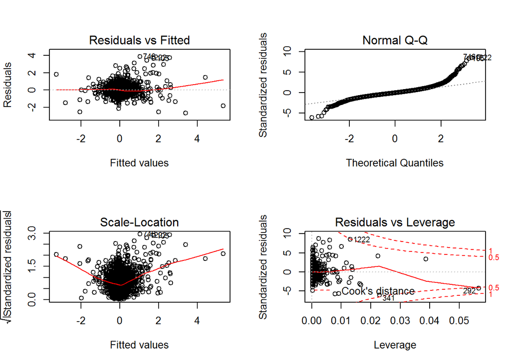

```r
par(mfrow = c(2,2))
plot(lrd)
```

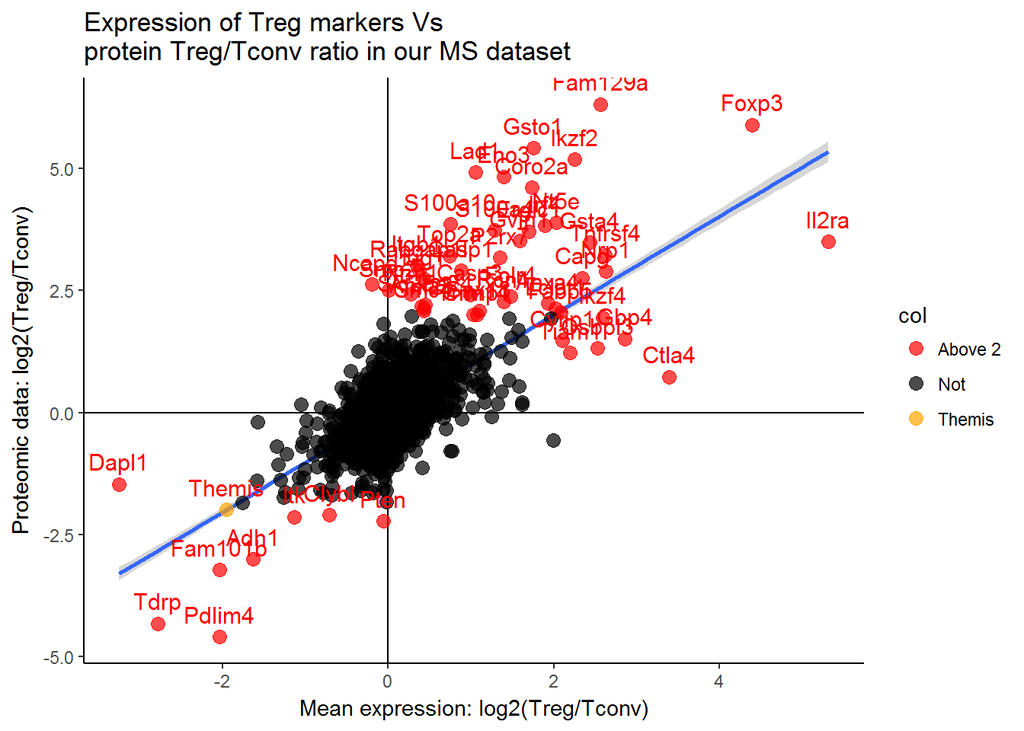

```r
tabg <- tab1

g <- ggplot(data = tabg, aes(y = FC, x = MeanExpression, label = lab)) + geom_vline(xintercept = 0) + geom_hline(yintercept = 0) + geom_smooth(method = lm, fullrange = TRUE) + geom_point(aes(col = col), alpha = 0.7, size = 3) + ggtitle("Expression of Treg markers Vs\nprotein Treg/Tconv ratio in our MS dataset") + theme_classic() + xlab("Mean expression: log2(Treg/Tconv)") + ylab("Proteomic data: log2(Treg/Tconv)") + scale_colour_manual(values = c("red", "Black", "orange")) + geom_text(col = "red", hjust = 0.5, vjust = -0.8, size = 4)
print(g)
```

```r
pdf("Figures//2PepOrMore//ExpressionCorrelation.pdf", useDingbats=FALSE, 11.69, 8.27) # width and height in inches.
g
dev.off()
```

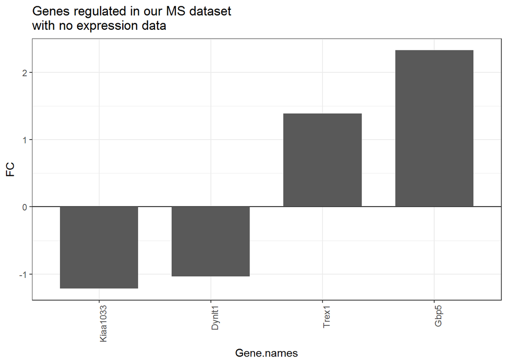

```r
# Proteomic data regulated and not present in the expression dataset:
reg <- tab10[abs(tab10$FC) >= 1 & tab10$adjpval<=0.05,]
nprotnoexp <- nrow(reg[is.na(reg$MeanExpression),])

tabg <- reg[is.na(reg$MeanExpression),]
tabg <- tabg[order(tabg$FC),]
tabg$Gene.names <- factor(as.character(tabg$Gene.names), levels = as.character(tabg$Gene.names))

g <- ggplot(tabg, aes(y = FC, x = Gene.names)) + geom_hline(yintercept = 0) + geom_bar(stat = "identity", width = 0.7) + theme_bw() + theme(axis.text.x = element_text(angle = 90, hjust = 1, size = 9)) + ggtitle("Genes regulated in our MS dataset\nwith no expression data")
print(g)
```

```r
# Make a column in the expression table that indicates if the gene is present in our MS dataset or not.
Pres <- rep("not in our MS dataset", nrow(nmat))
Pres[rownames(nmat) %in% as.character(tab$Gene.names)] <- "Present in our MS dataset"
exp <- cbind(nmat, "PresenceInOurDataset" = Pres, "Gene.name" = row.names(nmat))
#write.table(exp, "OutputTables//2PepOrMore/signatureFoxp3.txt", sep = "\t", row.names = F)
npresentInBoth <- length(unique(rownames(exp)[exp[,4]=="Present in our MS dataset"]))
npresentInExpOnly <- length(unique(rownames(exp)[exp[,4]!="Present in our MS dataset"]))
kable(data.frame(table(Pres))) # numbers of genes in the expression dataset that are present or not in our dataset.
```

| Pres | Freq |
| --- | --- |
| not in our MS dataset | 17125 |
| Present in our MS dataset | 3675 |

The table `OutputTables/2PepOrMore/signatureFoxp3.txt` contains the initial expression data with an additional column stating if the gene is quantified in our MS dataset.

The table `OutputTables/2PepOrMore/TableAll.txt` contains our result table with the additional columns of mean in each dataset, including a `mapping` column that is the first Majority protein ID that I use to merge the other datasets to ours (see the following section).

# Comparison with the proteomic dataset

Barra et al. 2015.

I use the Supplemental Table 1: Calculated dataset of proteins differentially expressed between Treg cells and Tconv cells.

I use all the protein accessions in the column `Accession` as input in [Uniprot ID mapper](http://www.uniprot.org/uploadlists/) to get all possible protein accessions of these proteins: `Raw/ProteomicsData/uniprot-yourlist%3AM2015113099G02LBX6Z-GenesMSinput.tab`.

Anne noticed that the gene Tdrp is not referenced in the table. I add it in the line with the protein.name “Uncharacterized protein C8orf42 homolog” (corresponds to Tdrp).

```
##
## Call:
## lm(formula = tab1$FC ~ tab1$ProteomicRatioTregTconv)
##
## Residuals:
##     Min      1Q  Median      3Q     Max
## -2.5812 -0.1880 -0.0247  0.1466  4.2550
##
## Coefficients:
##                               Estimate Std. Error t value Pr(>|t|)
## (Intercept)                  -0.033422   0.006934   -4.82  1.5e-06 ***
## tab1$ProteomicRatioTregTconv  0.782140   0.013797   56.69  < 2e-16 ***
## ---
## Signif. codes:  0 '***' 0.001 '**' 0.01 '*' 0.05 '.' 0.1 ' ' 1
##
## Residual standard error: 0.4093 on 3597 degrees of freedom
## Multiple R-squared:  0.4719, Adjusted R-squared:  0.4717
## F-statistic:  3214 on 1 and 3597 DF,  p-value: < 2.2e-16
```

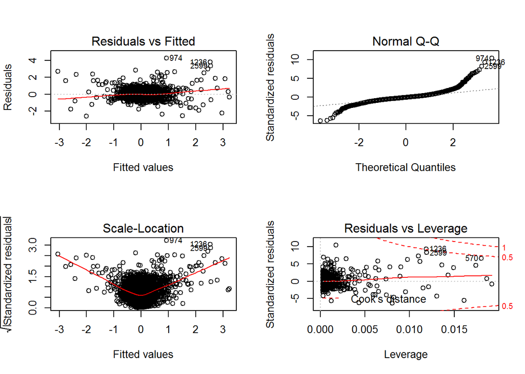

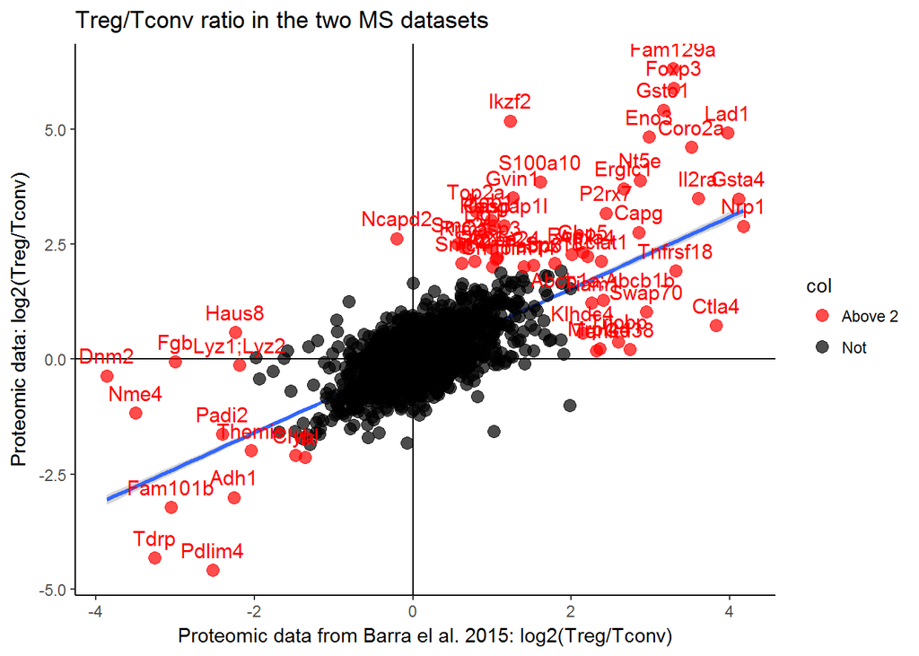

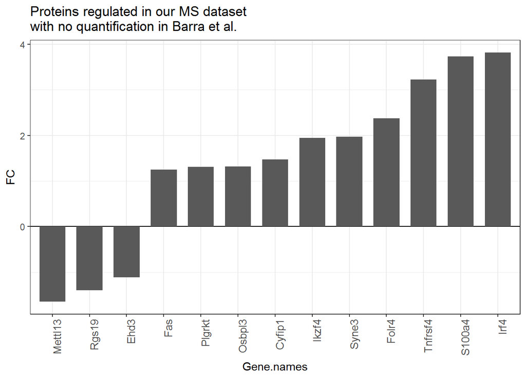

| Pres | Freq |
| --- | --- |
| not in our MS dataset | 1640 |
| Present in our MS dataset | 3678 |

There are 3612 unique genes that are present in the two tables (1564 are only identified in Barra et al. dataset). 13 genes are regulated in our dataset and are not in the Barra et al. dataset. In total, 375 genes are quantified in our dataset and absent of Barra et al. table. There are 3387 genes quantified in the 3 datasets.

# Creation heatmap with the three datasets.

In our dataset, there are 32 rows with no gene names, 3 corresponding to H2-D1 and 2 for Tmpo (these are different isoforms, in the case of Tmpo they don’t present the same abundancy).

For this figure, I manually remove the row with no gene name, and corresponding to `Majority.protein.IDs` == “P14427” and “P01900;P01895” for H2-D1 (highest pval, no adjusted pval); “Q61029” for Tmpo (highest pval, no adjusted pval).

In the proteomic data table, some isoforms remain (duplicated gene names). So I use `Accession` as row names. For each gene, I keep the quan value corresponding to the SwissProt identification with the maximum number of Unique + razor peptides.

For the tilemap, I select the genes that have a mean FC >= 1 or <= -1 in 2 datasets. Then, I present 50% of the top hits ordered by mean FC: `Figures/TregTconv3DS.pdf`.

```
##
##      Tmpo
##   32    2
```

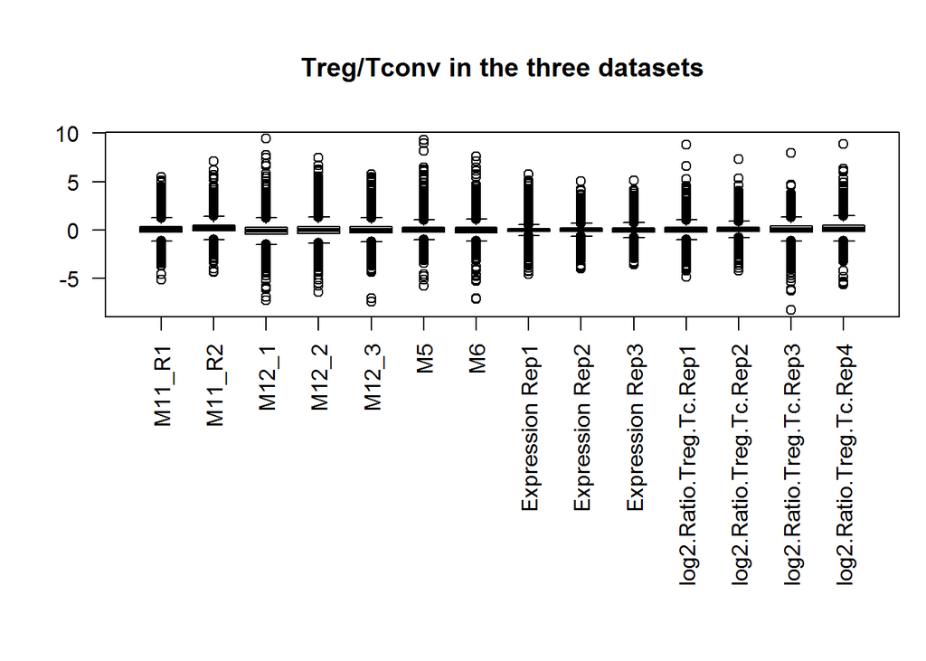

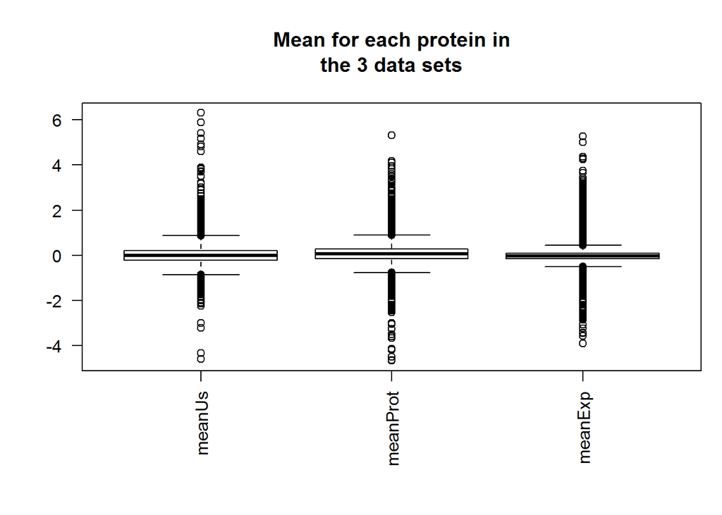

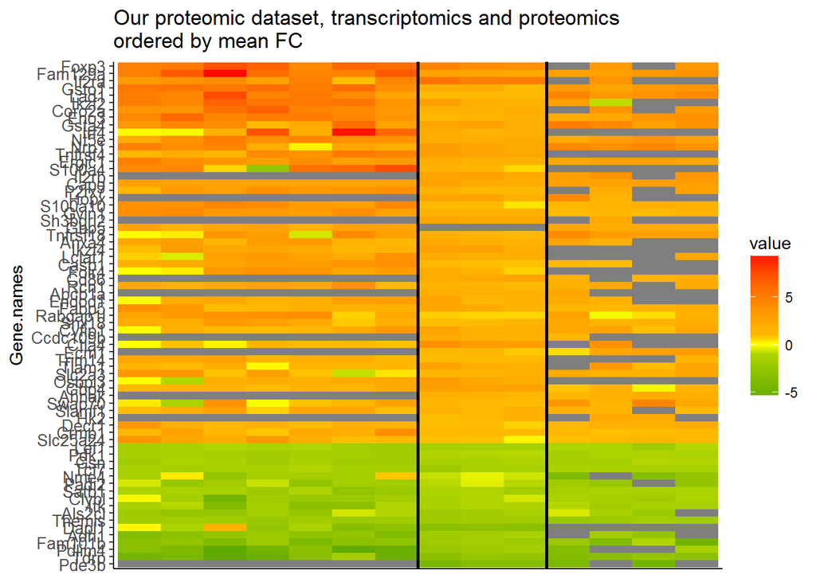

The table used for the final heatmap is: `OutputTables/2PepOrMore/HeatMapProtExp_Table.txt`.